# Stylometry for Authorship Analysis

Dana Roemling

2025-03-13

# R Code for Text Processing and Analysis

## Starting with `quanteda`

Quanteda is a library that focuses on text analysis, so it comes in quite handy when we do any kind of authorship analysis. The package further below, which is designed specifically for authorship analysis, build on quanteda, so we will start of here to give you some time (or code) to explore the ‘basics’.

```r
# Install and load the quanteda package for text processing
# install.packages("quanteda")
library(quanteda)
```

Reading in the files I have provided is likely going to trigger a warning each time a file is read. You can ignore them in this case, but if you want to suppress them:

```r
options(warn=-1)
# options(warn=0) restores the default.
```

You can either set the file path here or do that for the respective function alone.

```r
# Change this according to your system & needs
path_to_file <- "/Users/dana/Documents/Teaching (recent)/HY/Week 5/JEF_DIC/DIC_001.txt"
path_to_folder <- "/Users/dana/Documents/Teaching (recent)/HY/Week 5/JEF_DIC/"
path_to_known <- path_to_folder
path_to_disputed <- "/Users/dana/Documents/Teaching (recent)/HY/Week 5/DISPUTED"
```

## Average Sentence Length (Single)

If we want to calculate the ASL for a single text file, we first read in that file, process it into both sentences and tokens and then we can use those to calculate the ASL.

Please consider that ASL is dependent on several factors, for example genre and register, so blindly comparing the numbers might not give you the desired results.

```r
# Set the path to your text file
# path_to_file <- "/PATH/FILE_001.txt"

# Read the text file into R
text_data <- readLines(path_to_file)

# Create a corpus from the text data using quanteda
corpus <- corpus(text_data)

# Split the corpus into sentences
sentences <- corpus_reshape(corpus,
                            to = "sentences")

# Tokenise the sentences into words (keeping punctuation)
tokens <- tokens(sentences,
                 what = "word",
                 remove_punct = FALSE)

# Count the number of tokens (words) in each sentence
sentence_lengths <- sapply(tokens,
                           length)

# Print sentence lengths
print(sentence_lengths)
```

```
##  text1.1  text2.1  text3.1  text4.1  text5.1  text6.1  text7.1  text8.1
##       15       86       53      122       55       49       68       58
##  text9.1 text10.1 text11.1 text11.2 text12.1 text13.1 text14.1 text15.1
##       97       53      104       34      101      148      138       52
## text16.1 text16.2 text17.1 text18.1 text19.1 text20.1 text21.1 text22.1
##      128       31       12      439      182      166       12       46
## text22.2 text23.1 text24.1 text25.1 text26.1 text27.1 text28.1 text29.1
##      138       21       40      109       36      489       55      114
```

```r
# Calculate and print the average sentence length
average_sentence_length <- mean(sentence_lengths)
print(paste("Average sentence length: ",
            average_sentence_length))
```

```
## [1] "Average sentence length:  101.59375"
```

## Average Sentence Length (Multiple)

Rather than doing this for every file manually, we can also automate the process and calculate the ASL for every file in a folder, for example, and store the results in a dataframe that lets us visualise the results.

```r
# Define the function to process all .txt files in a folder
calculate_avg_sentence_length <- function(folder_path) {
  # Get the list of all .txt files in the folder
  file_list <- list.files(folder_path,
                          pattern = "\\.txt$",
                          full.names = TRUE)

  # Create an empty list to store the results
  results <- list()

  # Loop over each file
  for (file in file_list) {
    # Read the text file into R
    text_data <- readLines(file)

    # Create a corpus from the text data
    corpus <- corpus(text_data)

    # Split the corpus into sentences
    sentences <- corpus_reshape(corpus,
                                to = "sentences")

    # Tokenize the sentences into words
    tokens <- tokens(sentences,
                     what = "word",
                     remove_punct = FALSE)

    # Count the number of tokens (words) in each sentence
    sentence_lengths <- sapply(tokens,
                               length)

    # Calculate the average sentence length for the file
    avg_sentence_length <- mean(sentence_lengths)

    # Store the result
    results[[file]] <- avg_sentence_length
  }

  # Convert the results to a data frame
  results_df <- data.frame(
    File = names(results),
    Average_Sentence_Length = unlist(results)
  )

  return(results_df)
}

# Run the function
avg_sentence_lengths_df <- calculate_avg_sentence_length(path_to_folder)
rownames(avg_sentence_lengths_df) <- 1:nrow(avg_sentence_lengths_df)
```

In order to cluster our results by author, for example for visualisation, we iterate over the files and add an author column depending on the file name. We could also add this to the function above, but for clarity, I have seperated these steps.

```r
# Function to add author information to the results dataframe
add_author_info <- function(results_df) {

  # Extract just the filename (removing the full path)
  results_df$File <- basename(results_df$File)

  # Extract author name (assumes it's before the first underscore "_")
  results_df$Author <- gsub("_.*",
                            "",
                            results_df$File)  # Modify if needed for different formats

  return(results_df)
}

# Add author information to the dataframe
avg_sentence_lengths_df <- add_author_info(avg_sentence_lengths_df)
```

Now we can plot the results to see if the two authors, in our case, differ in their average sentence length.

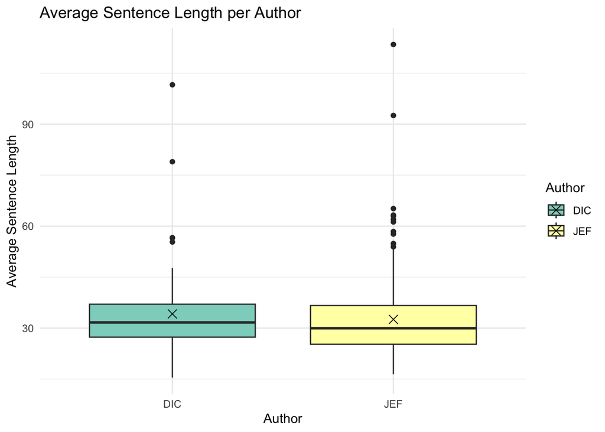

```r
# Create the boxplot using ggplot2
ggplot(avg_sentence_lengths_df,
       aes(x = Author,
           y = Average_Sentence_Length,
           fill = Author)
       ) +
  geom_boxplot() +
  stat_summary(fun = mean,
               geom = "point",
               shape = 4,
               size = 3,
               color = "black") +
  labs(
    title = "Average Sentence Length per Author",
    x = "Author",
    y = "Average Sentence Length"
  ) +
  theme_minimal() +
  scale_fill_brewer(palette = "Set3")
```

## Type Token Ratio (Single)

There are numerous features we might be interested in, but just as another example we will look at the Type Token Ratio. Please remember that this feature is DEPENDENT on text length and ideally you would normalise for text length.

```r
# Set the path to the text file
# path_to_file <- "/PATH/FILE_001.txt"

# Read the text file into R
text_data <- readLines(path_to_file)

# Create a corpus from the text data
corpus <- corpus(text_data)

# Tokenize the text
tokens <- tokens(corpus,
                 what = "word",
                 remove_punct = TRUE)

# Calculate the number of types (unique words)
num_types <- length(unique(unlist(tokens)))

# Calculate the number of tokens (total words)
num_tokens <- length(unlist(tokens))

# Compute Type-Token Ratio (TTR)
ttr <- num_types / num_tokens

# Print TTR
print(paste("Type-Token Ratio (TTR) for the document:",
            ttr))
```

```
## [1] "Type-Token Ratio (TTR) for the document: 0.248310810810811"
```

## Type Token Ratio (Multiple)

We can similarly automate this step.

```r
# Define a function to calculate TTR for all .txt files in a folder
calculate_ttr <- function(folder_path) {

  # Get the list of all .txt files in the folder
  file_list <- list.files(folder_path,
                          pattern = "\\.txt$",
                          full.names = TRUE)

  # Create an empty list to store results
  results <- list()

  # Loop over each file
  for (file in file_list) {
    # Read the text file into R
    text_data <- readLines(file)

    # Create a corpus from the text data
    corpus <- corpus(text_data)

    # Tokenize the text
    tokens <- tokens(corpus,
                     what = "word",
                     remove_punct = TRUE)

    # Calculate the number of types (unique words)
    num_types <- length(unique(unlist(tokens)))

    # Calculate the number of tokens (total words)
    num_tokens <- length(unlist(tokens))

    # Compute Type-Token Ratio (TTR)
    ttr <- num_types / num_tokens

    # Store the result (file name and TTR value)
    results[[file]] <- ttr
  }

  # Convert the results into a data frame
  results_df <- data.frame(
    File = names(results),
    Type_Token_Ratio = unlist(results)
  )

  return(results_df)
}

# Run the function
ttr_results_df <- calculate_ttr(path_to_folder)
rownames(ttr_results_df) <- 1:nrow(ttr_results_df)
```

In order to visualise by author, we need to add the author column again.

```r
# Function to extract author from filename
extract_author <- function(filepath) {
  filename <- basename(filepath)  # Get just the filename (remove the path)
  author <- strsplit(filename, "_")[[1]][1]  # Extract author (before first "_")
  return(author)
}

# Apply author extraction and add as a new column
ttr_results_df$Author <- sapply(ttr_results_df$File,
                                extract_author)
```

And now we can visualise the TTR.

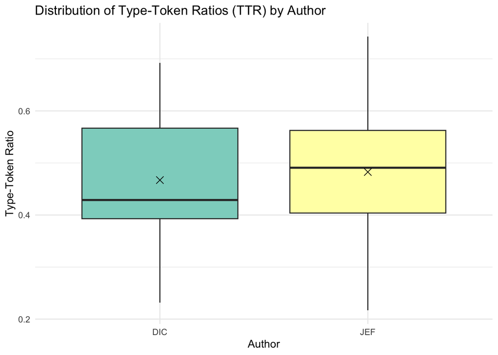

```r
ggplot(ttr_results_df,
       aes(x = Author,
           y = Type_Token_Ratio,
           fill = Author)
       ) +
  geom_boxplot() +
  stat_summary(fun = mean,
               geom = "point",
               shape = 4,
               size = 3,
               color = "black") +
  labs(title = "Distribution of Type-Token Ratios (TTR) by Author",
       x = "Author",
       y = "Type-Token Ratio") +
  theme_minimal() +
  theme(legend.position = "none") +
  scale_fill_brewer(palette = "Set3")
```

## Average Word Length (Single)

```r
# Set the path to your text file
# path_to_file <- "/PATH/FILE_001.txt"

# Read the text file into R
text_data <- readLines(path_to_file)

# Create a corpus from the text data
corpus <- corpus(text_data)

# Tokenize the corpus into words (removing punctuation)
tokens <- tokens(corpus,
                 what = "word",
                 remove_punct = TRUE)

# Flatten the tokens into a single vector of words
word_list <- unlist(tokens)

# Compute word lengths (number of characters per word)
word_lengths <- nchar(word_list)

# Calculate and print the average word length
average_word_length <- mean(word_lengths, na.rm = TRUE)
print(paste("Average word length: ", average_word_length))
```

```
## [1] "Average word length:  4.88209459459459"
```

## Average Word Length (Multiple)

Or, again, for the whole folder.

```r
# Define the function to process all .txt files in a folder
calculate_avg_word_length <- function(folder_path) {
  # Get the list of all .txt files in the folder
  file_list <- list.files(folder_path,
                          pattern = "\\.txt$",
                          full.names = TRUE)

  # Create an empty list to store the results
  results <- list()

  # Loop over each file
  for (file in file_list) {
    # Read the text file into R
    text_data <- readLines(file)

    # Create a corpus from the text data
    corpus <- corpus(text_data)

    tokens <- tokens(corpus,
                 what = "word",
                 remove_punct = TRUE)

    # Flatten the tokens into a single vector of words
    word_list <- unlist(tokens)

    # Compute word lengths (number of characters per word)
    word_lengths <- nchar(word_list)

    # Calculate the average word length for the file
    average_word_length <- mean(word_lengths, na.rm = TRUE)

    # Store the result
    results[[file]] <- average_word_length
  }

  # Convert the results to a data frame
  results_df <- data.frame(
    File = names(results),
    average_word_length = unlist(results)
  )

  return(results_df)
}

# Run the function
avg_word_lengths_df <- calculate_avg_word_length(path_to_folder)
rownames(avg_word_lengths_df) <- 1:nrow(avg_word_lengths_df)
```

Extracting the author name again.

```r
# Function to extract author from filename
extract_author <- function(filepath) {
  filename <- basename(filepath)  # Get just the filename (remove the path)
  author <- strsplit(filename, "_")[[1]][1]  # Extract author (before first "_")
  return(author)
}

# Apply author extraction and add as a new column
avg_word_lengths_df$Author <- sapply(avg_word_lengths_df$File,
                                     extract_author)
```

And now we can visualise the AWL.

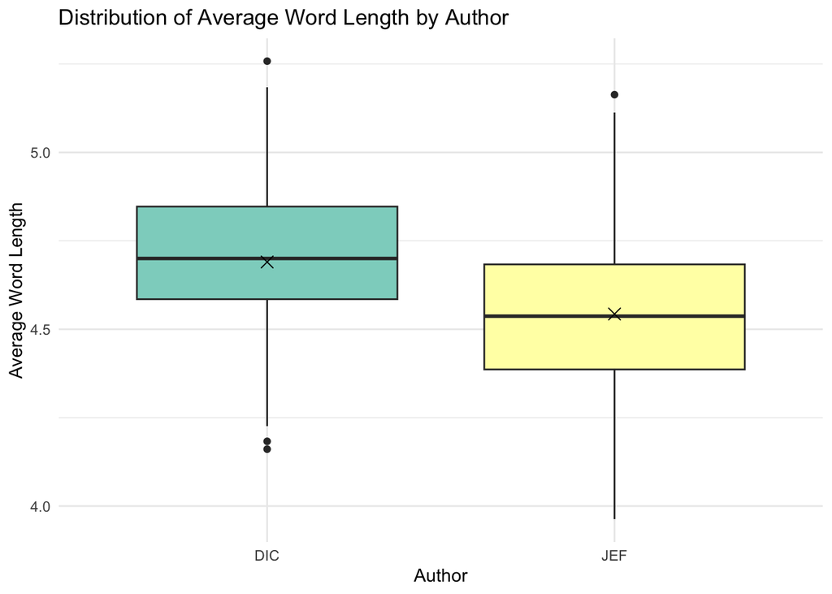

```r
ggplot(avg_word_lengths_df,
       aes(x = Author,
           y = average_word_length,
           fill = Author)
       ) +
  geom_boxplot() +
  stat_summary(fun = mean,
               geom = "point",
               shape = 4,
               size = 3,
               color = "black") +
  labs(title = "Distribution of Average Word Length by Author",
       x = "Author",
       y = "Average Word Length") +
  theme_minimal() +
  theme(legend.position = "none") +
  scale_fill_brewer(palette = "Set3")
```

## Comparison Analysis with `idiolect`

Let’s also make use of the idiolect package prepared by the forensic linguist Andrea Nini, who has also worked on the case we have discussed in class.

## Visualising n-gram traching

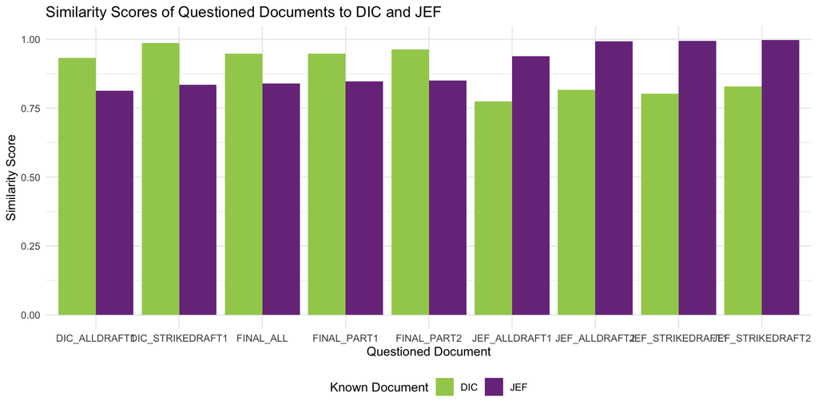

```r
# Create a bar plot to compare similarity scores
ggplot(ngrams,
       aes(x = Q,
           y = score,
           fill = K)
       ) +
  geom_bar(stat = "identity",
           position = "dodge") +  # Create side-by-side bars
  labs(title = "Similarity Scores of Questioned Documents to DIC and JEF",
       x = "Questioned Document",
       y = "Similarity Score",
       fill = "Known Document") +
  theme_minimal() +
  scale_fill_manual(values = c("darkolivegreen3",
                               "mediumorchid4")) +  # Set custom colors
  theme(legend.position = "bottom") +
  scale_x_discrete(labels = function(x) str_replace(x, ".txt", ""))  # Clean up x-axis labels
```